# Precipitation sinusoidal isocape model: kriging over NZ of sinusoidal parameters

Andy McKenzie (NIWA), Bruce Dudley (NIWA)

03 November, 2023

# 1 Load in data

## 1.1 Mean value climate data and predicted sinusoidal parameters

```r
# Mean value of climate data at an agent location, with appended columns for predicted value
#  - output from 02-isoscape-kriging-sinusoidal-parameters.Rmd
#  - load R object has name  "national.climate.summary"
load(file = "Output/Data/national.climate.summary.02.output.RData")
dim(national.climate.summary)
```

```
[1] 11491    24
```

```r
names(national.climate.summary)
```

```
 [1] "VCSN.Agent"        "VCSN.lat"          "VCSN.lon"
 [4] "MSLP"              "PET"               "RH"
 [7] "SoilM"             "ETmp"              "Rad"
[10] "VP"                "Wind"              "Rain_bc"
[13] "AnnualTempRange"   "height"            "island"
[16] "amp.pred"          "phase.pred"        "offset.pred"
[19] "allen.amp.pred"    "allen.phase.pred"  "allen.offset.pred"
[22] "krig.amp.pred"     "krig.phase.pred"   "krig.offset.pred"
```

## 1.2 The d18O observed values

```r
load(file = "Output/Data/ddata.RData")
glimpse(ddata)
```

```
Rows: 1,436
Columns: 8
$ Site         <dbl> 1, 1, 1, 1, 1, 1, 1, 1, 1, 1, 1, 1, 1, 1, 1, 1, 1, 1, 1, …
$ sample.id    <chr> "70801", "70901", "71001", "71101", "71201", "80101", "80…
$ year         <dbl> 2007, 2007, 2007, 2007, 2007, 2008, 2008, 2008, 2008, 200…
$ month        <dbl> 8, 9, 10, 11, 12, 1, 2, 3, 4, 5, 6, 7, 8, 9, 10, 11, 1, 3…
$ variable     <chr> "d18O", "d18O", "d18O", "d18O", "d18O", "d18O", "d18O", "…
$ d18O         <dbl> -4.41, -5.71, -2.74, -4.72, -2.54, -4.70, -8.13, -5.84, -…
$ agent.number <dbl> 20661, 20661, 20661, 20661, 20661, 20661, 20661, 20661, 2…
$ Date         <date> 2007-08-15, 2007-09-15, 2007-10-15, 2007-11-15, 2007-12-…
```

## 1.3 VCSN agent locations

```r
load(file = "Output/Data/vcsn.agent.locations.RData")
glimpse(vcsn.agent.locations)
```

```
Rows: 11,491
Columns: 4
$ Agent    <dbl> 3027, 3106, 3380, 4782, 5878, 7317, 7318, 7319, 7320, 7344, 7…
$ vcsn.lon <dbl> 166.825, 166.825, 166.825, 166.825, 166.825, 166.825, 166.825…
$ vcsn.lat <dbl> -45.325, -45.375, -45.425, -45.475, -45.525, -45.575, -45.625…
$ geometry <POINT [°]> POINT (166.825 -45.325), POINT (166.825 -45.375), POINT…
```

```r
load(file = "Output/Data/vcsn.agent.locations1.RData")
glimpse(vcsn.agent.locations1)
```

```
Rows: 11,491
Columns: 4
$ VCSN.Agent <dbl> 3027, 3106, 3380, 4782, 5878, 7317, 7318, 7319, 7320, 7344,…
$ vcsn.lon   <dbl> 166.825, 166.825, 166.825, 166.825, 166.825, 166.825, 166.8…
$ vcsn.lat   <dbl> -45.325, -45.375, -45.425, -45.475, -45.525, -45.575, -45.6…
$ geometry   <POINT [°]> POINT (166.825 -45.325), POINT (166.825 -45.375), POI…
```

## 1.4 VCSN climate means at all agent locations

```r
load(file = "Output/Data/vcsn.mean.RData")
dim(vcsn.mean)
```

```
[1] 11491    14
```

```r
names(vcsn.mean)
```

```
 [1] "Agent"           "lat"             "lon"             "MSLP"
 [5] "PET"             "RH"              "SoilM"           "ETmp"
 [9] "Rad"             "VP"              "Wind"            "Rain_bc"
[13] "AnnualTempRange" "height"
```

## 1.5 NZ grid for interpolating over

```r
load(file = "Output/Data/nzgrid.long.format.RData")
glimpse(nzgrid.long.format)
```

```
Rows: 10,685
Columns: 16
$ values          <dbl> 0, 0, 0, 0, 0, 0, 0, 0, 0, 0, 0, 0, 0, 0, 0, 0, 0, 0, …
$ Agent           <dbl> 20905, 21130, 21374, 21051, 21051, 20117, 20117, 21130…
$ lat             <dbl> -34.475, -34.475, -34.475, -34.425, -34.425, -34.475, …
$ lon             <dbl> 172.675, 172.725, 172.775, 172.875, 172.875, 172.975, …
$ MSLP            <dbl> 1017.178, 1017.233, 1017.290, 1017.435, 1017.435, 1017…
$ PET             <dbl> 3.017847, 3.011431, 2.939014, 2.984719, 2.984719, 2.98…
$ RH              <dbl> 84.75753, 84.68807, 84.61437, 84.36501, 84.36501, 84.3…
$ SoilM           <dbl> -54.89281, -55.20777, -55.53946, -57.33879, -57.33879,…
$ ETmp            <dbl> 15.96239, 15.93450, 15.24877, 15.74916, 15.74916, 15.8…
$ Rad             <dbl> 15.20607, 15.19507, 15.27101, 15.49581, 15.49581, 15.0…
$ VP              <dbl> 15.41465, 15.41598, 15.41884, 15.47909, 15.47909, 15.4…
$ Wind            <dbl> 8.114665, 7.935661, 7.822707, 7.588518, 7.588518, 7.15…
$ Rain_bc         <dbl> 3.609343, 3.633830, 3.637680, 3.318549, 3.318549, 3.39…
$ AnnualTempRange <dbl> 8.792061, 8.827671, 9.057456, 8.906373, 8.906373, 8.92…
$ height          <dbl> 62.1729, 68.3421, 123.1681, 94.0155, 94.0155, 58.5626,…
$ geometry        <POLYGON [m]> POLYGON ((1517701 6221506, ..., POLYGON ((1572…
```

## 1.6 Estimated sinusoidal parameters at sites, mean VCSN values, Allen predicted sinusoidal parameters

```r
load(file = "Output/Data/combine.vcsn.reg.RData")
dim(combine.vcsn.reg)
```

```
[1] 51 32
```

```r
names(combine.vcsn.reg)
```

```
 [1] "Site"                  "Amplitude"             "phase"
 [4] "offset"                "area"                  "height"
 [7] "island"                "VCSN.lat"              "VCSN.lon"
[10] "ETmp"                  "MSLP"                  "PET"
[13] "RH"                    "Rad"                   "Rain_bc"
[16] "SoilM"                 "VP"                    "Wind"
[19] "VCSN.Agent"            "AnnualTempRange"       "amp.pred"
[22] "phase.pred"            "offset.pred"           "allen.amp.pred"
[25] "allen.phase.pred"      "allen.offset.pred"     "amp.pred.err"
[28] "phase.pred.err"        "offset.pred.err"       "allen.amp.pred.err"
[31] "allen.phase.pred.err"  "allen.offset.pred.err"
```

## 1.7 RMSE by site

```r
load(file = "Output/Data/RMSE.by.site.RData")
dim(RMSE.by.site)
```

```
[1] 51  2
```

```r
names(RMSE.by.site)
```

```
[1] "Site" "RMSE"
```

## 1.8 VCSN data

```r
# cache = FALSE, as problems otherwise with large R object
load("ProcessedData/vcsn.2007.2022.RData")
glimpse(vcsn.2007.2022)
```

```
Rows: 67,153,404
Columns: 18
$ Agent   <dbl> 3027, 3106, 3380, 4782, 5878, 7317, 7318, 7319, 7320, 7344, 73…
$ Lat     <dbl> -45.325, -45.375, -45.425, -45.475, -45.525, -45.575, -45.625,…
$ Longt   <dbl> 166.825, 166.825, 166.825, 166.825, 166.825, 166.825, 166.825,…
$ Date    <date> 2007-01-01, 2007-01-01, 2007-01-01, 2007-01-01, 2007-01-01, 2…
$ MSLP    <dbl> 1018.1, 1018.3, 1018.5, 1018.7, 1018.8, 1019.0, 1019.2, 1019.4…
$ PET     <dbl> 3.3, 3.3, 3.3, 3.3, 3.2, 3.3, 3.3, 3.2, 3.3, 3.2, 3.3, 3.2, 3.…
$ Rain    <dbl> 0.0, 0.0, 0.0, 0.0, 0.0, 0.0, 0.0, 0.0, 0.0, 0.0, 0.0, 0.0, 0.…
$ RH      <dbl> 70.9, 71.0, 71.1, 71.7, 72.6, 72.4, 72.2, 71.6, 71.8, 71.9, 71…
$ SoilM   <dbl> 57.1, 57.3, 57.1, 67.2, 80.3, 76.1, 72.0, 60.5, 59.3, 59.3, 55…
$ ETmp    <dbl> 10.2, 10.3, 10.3, 10.4, 9.7, 11.3, 10.2, 9.6, 11.7, 9.5, 10.4,…
$ Rad     <dbl> 21.3, 21.1, 20.9, 20.7, 20.5, 20.3, 20.1, 19.9, 19.5, 19.3, 19…
$ TMax    <dbl> 17.6, 17.4, 17.1, 16.9, 15.8, 17.5, 15.7, 14.6, 16.8, 13.6, 14…
$ Tmin    <dbl> 5.1, 5.2, 5.2, 5.4, 4.5, 6.6, 5.2, 4.4, 7.5, 4.5, 5.9, 2.6, 4.…
$ VP      <dbl> 9.8, 9.8, 9.8, 9.7, 9.6, 9.6, 9.7, 9.7, 9.7, 9.7, 9.7, 9.7, 9.…
$ Wind    <dbl> 3.1, 4.0, 4.7, 4.1, 4.9, 5.1, 4.8, 6.0, 5.7, 5.7, 6.5, 7.3, 6.…
$ Rain_bc <dbl> 0.0, 0.0, 0.0, 0.0, 0.0, 0.0, 0.0, 0.0, 0.0, 0.0, 0.0, 0.0, 0.…
$ Tmax_N  <dbl> 17.9, 17.7, 17.3, 17.2, 15.9, 17.7, 15.8, 14.6, 16.7, 13.4, 14…
$ Tmin_N  <dbl> 6.6, 6.5, 6.4, 6.5, 5.8, 7.2, 6.2, 5.7, 7.7, 5.6, 6.5, 4.3, 5.…
```

```r
# Used latter in the code
vcsn.2007.2022cut <- vcsn.2007.2022[, c(1:4, 16)]

rm(vcsn.2007.2022)
```

# 2 Calculate monthly d18O values from amplitude, phase and offset maps

## 2.1 Append prediction columns for linear, Allen, and kriging models

```r
# note that this clunky code is Bruce's doing

# collection on 15th of each month
julian.day.month.midpoints <- c(15, 46, 74, 105, 135, 166, 196, 227, 258, 288, 319, 349)
julian.days <- julian.day.month.midpoints / 365
julian.days
```

```
 [1] 0.04109589 0.12602740 0.20273973 0.28767123 0.36986301 0.45479452
 [7] 0.53698630 0.62191781 0.70684932 0.78904110 0.87397260 0.95616438
```

```r
linear.model.18O.pred <- data.frame(
  amplitude = national.climate.summary$amp.pred, # Create dataframe
  phase = national.climate.summary$phase.pred,
  offset = national.climate.summary$offset.pred,
  VCSN.Agent = national.climate.summary$VCSN.Agent
)

Allen.model.18O.pred <- data.frame(
  amplitude = national.climate.summary$allen.amp.pred, # Create dataframe
  phase = national.climate.summary$allen.phase.pred,
  offset = national.climate.summary$allen.offset.pred,
  VCSN.Agent = national.climate.summary$VCSN.Agent
)

Krig.model.18O.pred <- data.frame(
  amplitude = national.climate.summary$krig.amp.pred, # Create dataframe
  phase = national.climate.summary$krig.phase.pred,
  offset = national.climate.summary$krig.offset.pred,
  VCSN.Agent = national.climate.summary$VCSN.Agent
)


# Function to predict 18O for linear model

calc_precip_isotope <- function(julian.fraction) {
  linear.model.18O.pred$amplitude * (sin(2 * pi * julian.fraction) - linear.model.18O.pred$phase) + linear.model.18O.pred$offset
}

calc_precip_isotope2 <- function(julian.fraction) {
  Allen.model.18O.pred$amplitude * (sin(2 * pi * julian.fraction) - Allen.model.18O.pred$phase) + Allen.model.18O.pred$offset
}

calc_precip_isotope3 <- function(julian.fraction) {
  Krig.model.18O.pred$amplitude * (sin(2 * pi * julian.fraction) - Krig.model.18O.pred$phase) + Krig.model.18O.pred$offset
}

# loop for rolling it through months and appending columns

for (i in julian.days) {
  # Create new column of d18O predictions
  new <- calc_precip_isotope(i)
  # Append new column
  linear.model.18O.pred[, ncol(linear.model.18O.pred) + 1] <- new
  colnames(linear.model.18O.pred)[ncol(linear.model.18O.pred)] <- paste0("new", i) # Rename column name
}

for (i in julian.days) {
  new <- calc_precip_isotope2(i) # Create new column of d18O predictions
  Allen.model.18O.pred[, ncol(Allen.model.18O.pred) + 1] <- new # Append new column
  colnames(Allen.model.18O.pred)[ncol(Allen.model.18O.pred)] <- paste0("new", i) # Rename column name
}

for (i in julian.days) {
  new <- calc_precip_isotope3(i) # Create new column of d18O predictions
  Krig.model.18O.pred[, ncol(Krig.model.18O.pred) + 1] <- new # Append new column
  colnames(Krig.model.18O.pred)[ncol(Krig.model.18O.pred)] <- paste0("new", i) # Rename column name
}


names(linear.model.18O.pred) <- c("amplitude", "phase", "offset", "VCSN.Agent", "1", "2", "3", "4", "5", "6", "7", "8", "9", "10", "11", "12")

names(Allen.model.18O.pred) <- c("amplitude", "phase", "offset", "VCSN.Agent", "1", "2", "3", "4", "5", "6", "7", "8", "9", "10", "11", "12")

names(Krig.model.18O.pred) <- c("amplitude", "phase", "offset", "VCSN.Agent", "1", "2", "3", "4", "5", "6", "7", "8", "9", "10", "11", "12")

head(linear.model.18O.pred)
```

| amplitude | phase | offset | VCSN.Agent | 1 | 2 | 3 | 4 | 5 | 6 | 7 | 8 | 9 | 10 | 11 | 12 |
| --- | --- | --- | --- | --- | --- | --- | --- | --- | --- | --- | --- | --- | --- | --- | --- |
| 0.5384916 | -1.359936 | -5.804859 | 3027 | -4.935039 | -4.689324 | -4.557620 | -4.549067 | -4.679684 | -4.921643 | -5.196562 | -5.445871 | -5.591366 | -5.594916 | -5.455766 | -5.218992 |
| 0.5299052 | -1.332696 | -5.816522 | 3106 | -4.975007 | -4.733209 | -4.603606 | -4.595189 | -4.723723 | -4.961824 | -5.232360 | -5.477693 | -5.620868 | -5.624362 | -5.487430 | -5.254432 |
| 0.4258127 | -1.322826 | -6.106677 | 3380 | -5.434668 | -5.240368 | -5.136224 | -5.129461 | -5.232746 | -5.424075 | -5.641468 | -5.838609 | -5.953659 | -5.956466 | -5.846433 | -5.659204 |
| 0.6039600 | -1.366927 | -6.012254 | 4782 | -5.032462 | -4.756873 | -4.609158 | -4.599565 | -4.746062 | -5.017437 | -5.325781 | -5.605400 | -5.768583 | -5.772565 | -5.616498 | -5.350937 |
| 0.6835257 | -1.403011 | -5.786555 | 5878 | -4.653020 | -4.341125 | -4.173949 | -4.163093 | -4.328889 | -4.636016 | -4.984980 | -5.301436 | -5.486117 | -5.490624 | -5.313996 | -5.013451 |
| 0.6727088 | -1.355334 | -6.408588 | 7317 | -5.325064 | -5.018105 | -4.853575 | -4.842890 | -5.006063 | -5.308329 | -5.651771 | -5.963219 | -6.144978 | -6.149413 | -5.975580 | -5.679791 |

```r
linear.model.18O.long <- gather(linear.model.18O.pred, month, d18O, as.character(1:12), factor_key = TRUE)
Allen.model.18O.long <- gather(Allen.model.18O.pred, month, d18O, as.character(1:12), factor_key = TRUE)
Krig.model.18O.long <- gather(Krig.model.18O.pred, month, d18O, as.character(1:12), factor_key = TRUE)


head(linear.model.18O.long)
```

| amplitude | phase | offset | VCSN.Agent | month | d18O |
| --- | --- | --- | --- | --- | --- |
| 0.5384916 | -1.359936 | -5.804859 | 3027 | 1 | -4.935039 |
| 0.5299052 | -1.332696 | -5.816522 | 3106 | 1 | -4.975007 |
| 0.4258127 | -1.322826 | -6.106677 | 3380 | 1 | -5.434668 |
| 0.6039600 | -1.366927 | -6.012254 | 4782 | 1 | -5.032462 |
| 0.6835257 | -1.403011 | -5.786555 | 5878 | 1 | -4.653020 |
| 0.6727088 | -1.355334 | -6.408588 | 7317 | 1 | -5.325064 |

```r
head(Allen.model.18O.long)
```

| amplitude | phase | offset | VCSN.Agent | month | d18O |
| --- | --- | --- | --- | --- | --- |
| 0.3507293 | -1.679505 | -6.206400 | 3027 | 1 | -5.527788 |
| 0.3717117 | -1.674068 | -6.213213 | 3106 | 1 | -5.496024 |
| 0.3419275 | -1.668630 | -6.414461 | 3380 | 1 | -5.756598 |
| 0.3701598 | -1.663193 | -6.353612 | 4782 | 1 | -5.643444 |
| 0.4325149 | -1.657755 | -6.323742 | 5878 | 1 | -5.496294 |
| 0.3146681 | -1.652317 | -6.323906 | 7317 | 1 | -5.723624 |

```r
head(Krig.model.18O.long)
```

| amplitude | phase | offset | VCSN.Agent | month | d18O |
| --- | --- | --- | --- | --- | --- |
| 0.8003208 | -1.658909 | -5.573969 | 3027 | 1 | -4.041945 |
| 0.8003208 | -1.658909 | -5.573969 | 3106 | 1 | -4.041945 |
| 0.7638575 | -1.707210 | -5.559367 | 3380 | 1 | -4.060249 |
| 0.7394333 | -1.699030 | -5.633789 | 4782 | 1 | -4.188653 |
| 0.6265978 | -1.584267 | -5.868440 | 5878 | 1 | -4.715738 |
| 0.6352612 | -1.643434 | -5.631993 | 7317 | 1 | -4.425767 |

```r
linear.model.18O.long$VCSN.Agent <- as.character(linear.model.18O.long$VCSN.Agent)
linear.model.18O.long$month <- as.character(linear.model.18O.long$month)
Allen.model.18O.long$VCSN.Agent <- as.character(Allen.model.18O.long$VCSN.Agent)
Allen.model.18O.long$month <- as.character(Allen.model.18O.long$month)
Krig.model.18O.long$VCSN.Agent <- as.character(Krig.model.18O.long$VCSN.Agent)
Krig.model.18O.long$month <- as.character(Krig.model.18O.long$month)

linear.model.18O.long <- linear.model.18O.long[, 4:6]
Allen.model.18O.long <- Allen.model.18O.long[, 4:6]
Krig.model.18O.long <- Krig.model.18O.long[, 4:6]

names(linear.model.18O.long) <- c("VCSN.Agent", "month", "d18O.lin")
names(Allen.model.18O.long) <- c("VCSN.Agent", "month", "d18O.Allen")
names(Krig.model.18O.long) <- c("VCSN.Agent", "month", "d18O.krig")
```

Make an ‘uncorrected’ file for later testing against corrected isoscapes

```r
unco.frame<-linear.model.18O.long
unco.frame$unco.Allen<-Allen.model.18O.long$d18O.Allen
unco.frame$unco.krig<-Krig.model.18O.long$d18O.krig
colnames(unco.frame)[3] <-"unco.lin"
head(unco.frame)
```

| VCSN.Agent | month | unco.lin | unco.Allen | unco.krig |
| --- | --- | --- | --- | --- |
| 3027 | 1 | -4.935039 | -5.527788 | -4.041945 |
| 3106 | 1 | -4.975007 | -5.496024 | -4.041945 |
| 3380 | 1 | -5.434668 | -5.756598 | -4.060249 |
| 4782 | 1 | -5.032462 | -5.643444 | -4.188653 |
| 5878 | 1 | -4.653020 | -5.496294 | -4.715738 |
| 7317 | 1 | -5.325064 | -5.723624 | -4.425767 |

## 2.2 Comparison of modelled and measured data

First make a version of the original data file with month-of-the-year means for each measurement site. This is for comparison to and correction of the models.

```r
meandata <- ddata |>
  dplyr::select(month, d18O, agent.number) |> # select the named columns
  group_by(month, agent.number) |> # group by site and npid
  dplyr::summarise(value = mean(d18O)) |> # calculate mean values
  ungroup() |> # ungroup
  na.omit()
names(meandata) <- c("month", "VCSN.Agent", "d18O.measured")
```

Then glue the predictions for each of the three methods to this data frame.

```r
meandata$month <- as.character(meandata$month)
meandata$VCSN.Agent <- as.character(meandata$VCSN.Agent)
joindata1 <- left_join(meandata, linear.model.18O.long,
                       by = c("month" = "month", "VCSN.Agent" = "VCSN.Agent"))
joindata2 <- left_join(joindata1, Allen.model.18O.long,
                       by = c("month" = "month", "VCSN.Agent" = "VCSN.Agent"))
joindata3 <- left_join(joindata2, Krig.model.18O.long,
                       by = c("month" = "month", "VCSN.Agent" = "VCSN.Agent"))
rm(joindata1)
rm(joindata2)
```

```r
resids.frame <- data.frame(
  month = joindata3$month,
  VCSN.Agent = joindata3$VCSN.Agent,
  lin.resid = (joindata3$d18O.lin - joindata3$d18O.measured),
  Allen.resid = (joindata3$d18O.Allen - joindata3$d18O.measured),
  Krig.resid = (joindata3$d18O.krig - joindata3$d18O.measured)
)

vcsn.agent.locations1$VCSN.Agent <- as.character(vcsn.agent.locations1$VCSN.Agent)
resids.frame <- left_join(resids.frame, vcsn.agent.locations1, by = c("VCSN.Agent" = "VCSN.Agent"))
vcsn.mean$Agent <- as.character(vcsn.mean$Agent)
resids.frame <- left_join(resids.frame, vcsn.mean, by = c("VCSN.Agent" = "Agent"))
resids.frame <- resids.frame[, c(1:8, 11:21)]
```

Next, create residuals map for a single model*month combination. Then apply this as a correction to the models at the full VCSN scale. Then loop it through the other 35 month*model combinations!

## 2.3 Warm-up residual map for a single model and month combindation

```r
test.dataset<-dplyr::filter(resids.frame, month == "12")
```

```r
# NZTM
crs_projected_target <- "EPSG:2193"

test.dataset.proj <- st_as_sf(test.dataset,
  coords = c("vcsn.lon", "vcsn.lat"),
  remove = FALSE,
  crs = 4326
) |>
  st_transform(crs = crs_projected_target)
```

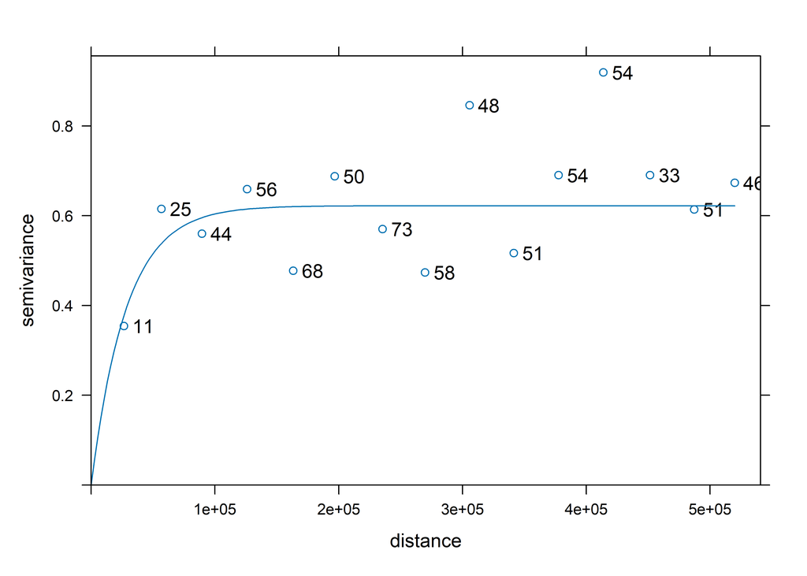

```r
resid.trend <- gstat::variogram(lin.resid ~ Rain_bc + ETmp, test.dataset.proj)
lin.resid.trend.model <- gstat::fit.variogram(resid.trend, vgm(model = "Exp"))

plot(resid.trend, lin.resid.trend.model, plot.numbers = TRUE)
```

```r
save(lin.resid.trend.model, file = "Output/MonthlyResiduals/lin.resid.trend.model.RData")
```

Apply residual trend kriging model over NZ.

```r
lin.resid.krig.trend <- gstat::krige(lin.resid ~ Rain_bc + ETmp,
                           test.dataset.proj,
                           nzgrid.long.format,
                           lin.resid.trend.model)
```

```
[using universal kriging]
```

```r
save(lin.resid.krig.trend, file = "Output/MonthlyResiduals/lin.resid.krig.trend.RData")
```

and plot the residuals for fun

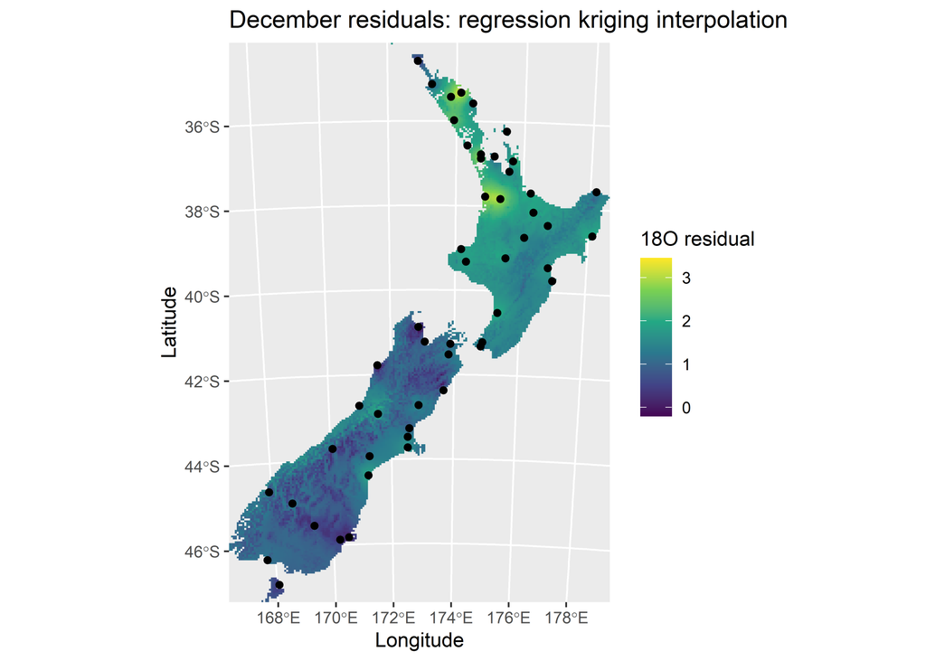

```r
lin.resid.krig.trend.stars <- stars::st_as_stars(lin.resid.krig.trend)

plot.lin.resid.krig.trend <-
  ggplot() +
    geom_stars(data = lin.resid.krig.trend.stars, aes(fill = var1.pred)) +
    geom_sf(data = test.dataset.proj) +
    coord_sf(expand = FALSE) +
    scale_fill_continuous(type = "viridis") +
    labs(fill = "18O residual") +
    xlab("Longitude") +
    ylab("Latitude") +
    ggtitle("December residuals: regression kriging interpolation")

plot.lin.resid.krig.trend
```

compare with ordinary kriging

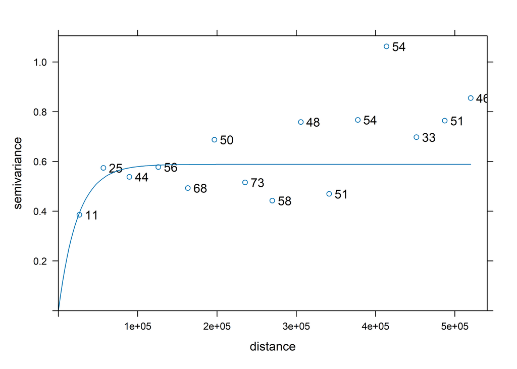

```r
resid.trend2  <- gstat::variogram(lin.resid ~ 1, test.dataset.proj)

resid.trend2.model <- gstat::fit.variogram(resid.trend2, vgm(model = "Exp"))
plot(resid.trend2, resid.trend2.model, plot.numbers = TRUE)
```

Apply constant kriging model over NZ.

```r
krig.constant.resid <- gstat::krige(lin.resid ~ 1,
                           test.dataset.proj,
                           nzgrid.long.format,
                           resid.trend2.model)
```

```
[using ordinary kriging]
```

Plot the ordinary kriging model

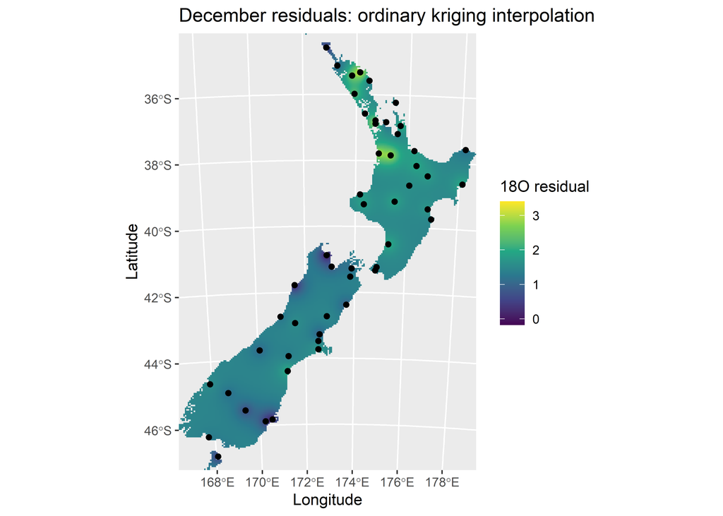

```r
krig.constant.resid.stars <- stars::st_as_stars(krig.constant.resid)

plot.krig.constant.resid <-
ggplot() +
  geom_stars(data = krig.constant.resid.stars, aes(fill = var1.pred)) +
  geom_sf(data = test.dataset.proj) +
  coord_sf(expand = FALSE) +
  scale_fill_continuous(type = "viridis") +
  labs(fill = "18O residual") +
  xlab("Longitude") +
  ylab("Latitude") +
  ggtitle("December residuals: ordinary kriging interpolation")

plot.krig.constant.resid
```

## 2.4 Residual map for all model and month combindation

Both of the efforts above look a bit useless. Do some exploratory regressions to see if there is a more useful predictor of residuals for this model. ETmp, and a combination of ETmp and SoilM look generally good.

```r
head(resids.frame)
```

| month | VCSN.Agent | lin.resid | Allen.resid | Krig.resid | vcsn.lon | vcsn.lat | geometry | MSLP | PET | RH | SoilM | ETmp | Rad | VP | Wind | Rain_bc | AnnualTempRange | height |
| --- | --- | --- | --- | --- | --- | --- | --- | --- | --- | --- | --- | --- | --- | --- | --- | --- | --- | --- |
| 1 | 7524 | -0.0983098 | -0.3713237 | -1.4305552 | 167.725 | -46.275 | POINT (167.725 -46.275) | 1012.181 | 2.185832 | 84.06480 | -25.390503 | 9.848323 | 11.56608 | 10.276078 | 4.082016 | 3.465298 | 11.133811 | 29.5393 |
| 1 | 7697 | 0.7708644 | 0.4457288 | 0.9097009 | 167.925 | -44.675 | POINT (167.925 -44.675) | 1014.201 | 2.421920 | 88.93128 | 6.512834 | 10.684668 | 11.07941 | 10.575582 | 2.698272 | 18.476694 | 11.108203 | 484.8302 |
| 1 | 10134 | -0.7661327 | -1.3024882 | 0.1358746 | 168.075 | -46.875 | POINT (168.075 -46.875) | 1011.939 | 2.191478 | 85.66703 | -26.466170 | 8.739562 | 10.91444 | 10.817659 | 6.354107 | 3.673939 | 8.690481 | 69.8783 |
| 1 | 13051 | 0.2939884 | 1.0640366 | -0.3563712 | 169.375 | -45.525 | POINT (169.375 -45.525) | 1013.141 | 2.156913 | 78.24211 | -77.920739 | 8.426164 | 13.20551 | 9.141051 | 3.325257 | 1.488039 | 16.163378 | 497.5336 |
| 1 | 14132 | 0.5830206 | 0.7297793 | 0.3287143 | 170.225 | -45.875 | POINT (170.225 -45.875) | 1012.606 | 2.162166 | 79.99182 | -57.025017 | 10.665691 | 12.54966 | 9.555715 | 3.759189 | 1.775821 | 11.989104 | 10.2434 |
| 1 | 14371 | 0.6166705 | 1.2845612 | 1.9213057 | 168.675 | -44.975 | POINT (168.675 -44.975) | 1013.416 | 2.325274 | 77.49933 | -55.355921 | 7.790879 | 13.83123 | 8.864802 | 3.894404 | 2.016307 | 15.878840 | 656.0498 |

First loop through the monthly linear model residuals

```r
# NZTM
crs_projected_target <- "EPSG:2193"

resids.frame.proj <- st_as_sf(resids.frame,
  coords = c("vcsn.lon", "vcsn.lat"),
  remove = FALSE,
  crs = 4326
) |>
  st_transform(crs = crs_projected_target)

monthly <- unique(resids.frame.proj$month)

for (mth in monthly) {
  resids.frame1 <- resids.frame.proj[resids.frame.proj$month == mth, ]
  resid.trend   <- gstat::variogram(lin.resid ~ ETmp + SoilM, resids.frame1)
  trend.model   <- gstat::fit.variogram(resid.trend, vgm(model = "Exp"))
  krig.trend    <- gstat::krige(
    lin.resid ~ ETmp + SoilM,
    resids.frame1,
    nzgrid.long.format,
    trend.model
  )
  agent.CRS <- sf::st_crs(vcsn.agent.locations1)
  krig.trend.sf <- krig.trend |> sf::st_transform(crs = agent.CRS)
  kriging.row.index1 <- sf::st_nearest_feature(vcsn.agent.locations, krig.trend.sf)
  # Make a new column of residuals
  new <- krig.trend.sf$var1.pred[kriging.row.index1]
  # Append new column
  vcsn.agent.locations1[, ncol(vcsn.agent.locations1) + 1] <- new
  # Rename column name
  colnames(vcsn.agent.locations1)[ncol(vcsn.agent.locations1)] <- paste0("lin.resids.", mth)
}
```

```
[using universal kriging]
[using universal kriging]
[using universal kriging]
[using universal kriging]
[using universal kriging]
[using universal kriging]
[using universal kriging]
[using universal kriging]
[using universal kriging]
[using universal kriging]
[using universal kriging]
[using universal kriging]
```

```r
save(vcsn.agent.locations1, file = "Output/MonthlyResiduals/final.residuals.data.RData")
```

Check on column names after doing the appending of new columns.

```r
head(vcsn.agent.locations1)
```

| VCSN.Agent | vcsn.lon | vcsn.lat | geometry | lin.resids.1 | lin.resids.2 | lin.resids.3 | lin.resids.4 | lin.resids.5 | lin.resids.6 | lin.resids.7 | lin.resids.8 | lin.resids.9 | lin.resids.10 | lin.resids.11 | lin.resids.12 |
| --- | --- | --- | --- | --- | --- | --- | --- | --- | --- | --- | --- | --- | --- | --- | --- |
| 3027 | 166.825 | -45.325 | POINT (166.825 -45.325) | 0.9316351 | 4.707695 | 2.434989 | 3.298893 | 4.579111 | 2.492210 | 2.160856 | 2.506199 | 0.8843929 | 0.3536217 | 0.3449764 | 1.141426 |
| 3106 | 166.825 | -45.375 | POINT (166.825 -45.375) | 0.9316351 | 4.707695 | 2.434989 | 3.298893 | 4.579111 | 2.492210 | 2.160856 | 2.506199 | 0.8843929 | 0.3536217 | 0.3449764 | 1.141426 |
| 3380 | 166.825 | -45.425 | POINT (166.825 -45.425) | 0.8317414 | 4.638455 | 2.401988 | 3.180530 | 4.374235 | 2.379999 | 2.113563 | 2.527740 | 0.8766881 | 0.3469846 | 0.3006916 | 1.095144 |
| 4782 | 166.825 | -45.475 | POINT (166.825 -45.475) | 0.7962238 | 4.628507 | 2.380681 | 3.130880 | 4.275191 | 2.327569 | 2.088964 | 2.529964 | 0.8693378 | 0.3404095 | 0.2954883 | 1.079273 |
| 5878 | 166.825 | -45.525 | POINT (166.825 -45.525) | 0.8656042 | 4.858042 | 2.274804 | 3.112370 | 4.194339 | 2.246257 | 2.008220 | 2.445225 | 0.8134190 | 0.2904674 | 0.4590040 | 1.116250 |
| 7317 | 166.825 | -45.575 | POINT (166.825 -45.575) | 1.2896291 | 5.182925 | 2.403109 | 3.664813 | 4.362098 | 2.359876 | 2.152334 | 2.276125 | 0.8710272 | 0.3353655 | 0.6181431 | 1.319227 |

Second and third loop through, adding as new monthly columns, correction layers for the Allen and Universal kriging approaches.

```r
# For Allen residuals
for (mth in monthly) {
  resids.frame1 <- resids.frame.proj[resids.frame.proj$month == mth, ]
  resid.trend <- gstat::variogram(Allen.resid ~ ETmp+SoilM, resids.frame1)
  trend.model <- gstat::fit.variogram(resid.trend, vgm(model = "Exp"))
  krig.trend  <- gstat::krige(Allen.resid ~ ETmp+SoilM,
                           resids.frame1,
                           nzgrid.long.format,
                           trend.model)
  agent.CRS <- sf::st_crs(vcsn.agent.locations1)
  krig.trend.sf <- krig.trend |>  sf::st_transform(crs = agent.CRS)
  kriging.row.index1 <- sf::st_nearest_feature(vcsn.agent.locations, krig.trend.sf)
 # Make a new column of residuals
  new <- krig.trend.sf$var1.pred[kriging.row.index1]
   # Append new column
  vcsn.agent.locations1[ , ncol(vcsn.agent.locations1) + 1] <- new
  # Rename column name and include month
  colnames(vcsn.agent.locations1)[ncol(vcsn.agent.locations1)] <- paste0("Allen.resids.", mth)
}
```

```
[using universal kriging]
[using universal kriging]
[using universal kriging]
[using universal kriging]
[using universal kriging]
[using universal kriging]
[using universal kriging]
[using universal kriging]
[using universal kriging]
[using universal kriging]
[using universal kriging]
[using universal kriging]
```

```r
# For kriging residuals
for (mth in monthly) {
  resids.frame1 <- resids.frame.proj[resids.frame.proj$month == mth, ]
  resid.trend <- gstat::variogram(Krig.resid ~ ETmp+SoilM, resids.frame1)
  trend.model <- gstat::fit.variogram(resid.trend, vgm(model = "Exp"))
  krig.trend <-  gstat::krige(Krig.resid ~ ETmp+SoilM,
                           resids.frame1,
                           nzgrid.long.format,
                           trend.model)
  agent.CRS <- sf::st_crs(vcsn.agent.locations1)
  krig.trend.sf <- krig.trend |>  sf::st_transform(crs = agent.CRS)
  kriging.row.index1 <- sf::st_nearest_feature(vcsn.agent.locations, krig.trend.sf)
 # Make a new column of residuals
  new <- krig.trend.sf$var1.pred[kriging.row.index1]
  # Append new column
  vcsn.agent.locations1[ , ncol(vcsn.agent.locations1) + 1] <- new
 # Rename column name and include month
  colnames(vcsn.agent.locations1)[ncol(vcsn.agent.locations1)] <- paste0("Krig.resids.", mth)
}
```

```
[using universal kriging]
[using universal kriging]
[using universal kriging]
[using universal kriging]
[using universal kriging]
[using universal kriging]
[using universal kriging]
[using universal kriging]
[using universal kriging]
[using universal kriging]
[using universal kriging]
[using universal kriging]
```

```r
save(vcsn.agent.locations1, file = "Output/MonthlyResiduals/finalfinal.residuals.data.RData")
```

# 3 Make final monthly isoscapes

## 3.1 Full linear model isoscape with kriging correction

```r
# CHECK
# Order for months is 1, 10, 11, 12, 2, 3, ..., 9
# select not needed, as these are the only three columns
# No rows removed by na.omit()
fatlin18Oframe <- linear.model.18O.long |>
  dplyr::select(VCSN.Agent, month, d18O.lin) |> # select the named columns
  spread(month, d18O.lin) |> # convert from long to wide format
  ungroup() |> # ungroup
  na.omit()

# Only 16 columns in vcsn.agent.locations1
linresids <- vcsn.agent.locations1[, c(1:16)]
linsubtract <- dplyr::left_join(linresids, fatlin18Oframe, by = "VCSN.Agent")
linsubtract <- linsubtract[, c(1:17, 21:28, 18:20)]
linsubtract <- as.data.frame(linsubtract)

chop1 <- linsubtract[, 17:28]
chop2 <- linsubtract[, 5:16]
chop3 <- chop1 - chop2

linmodelfinal <- cbind((vcsn.agent.locations1[, c(1:4)]), chop3)
linmodel.df <- as.data.frame(linmodelfinal)
linmodel.df <- linmodel.df[, c(1:3, 16, 4:15)]
linmodel.df <- gather(linmodel.df, month, "lin18O", 5:16, factor_key = TRUE)
linmodel.df$month <- stringr::str_replace(linmodel.df$month, "X", "")
#rm(chop1, chop2, chop3)
```

## 3.2 Allen et al. 2018 sinusoidal isoscape with kriging correction

```r
fatAllen18Oframe <- Allen.model.18O.long |>
  dplyr::select(VCSN.Agent, month,  d18O.Allen) |>   # select the named columns
  spread(month, d18O.Allen) |>   # convert from long to wide format
  dplyr::ungroup() |>
  na.omit()

Allenresids<-vcsn.agent.locations1[,c(1:4, 17:28)]
Allensubtract<-dplyr::left_join(Allenresids,fatAllen18Oframe,  by = "VCSN.Agent")
Allensubtract<-Allensubtract[,c(1:17,21:28,18:20)]
Allensubtract<-as.data.frame(Allensubtract)
chop1<-Allensubtract[,17:28]
chop2<-Allensubtract[,5:16]
chop3<-chop1-chop2
Allenmodelfinal<-cbind((vcsn.agent.locations1[,c(1:4)]), chop3)
Allenmodel.df<-as.data.frame(Allenmodelfinal)
Allenmodel.df<-Allenmodel.df[,c(1:3,16,4:15)]
Allenmodel.df <- gather(Allenmodel.df, month, "Allen18O", 5:16, factor_key=TRUE)
Allenmodel.df$month <- stringr::str_replace(Allenmodel.df$month, "X", "")
rm(Allenresids, Allensubtract, chop1, chop2, chop3)
```

## 3.3 Kriging model isoscape with second kriging correction

```r
fatKrig18Oframe <- Krig.model.18O.long |>
  dplyr::select(VCSN.Agent, month,  d18O.krig) |>     # select the named columns
  spread(month, d18O.krig) |>    # convert from long to wide format
  ungroup() |>   # ungroup
  na.omit()

Krigresids<-vcsn.agent.locations1[,c(1:4, 29:40)]
Krigsubtract<-dplyr::left_join(Krigresids,fatKrig18Oframe,  by = "VCSN.Agent")
Krigsubtract<-Krigsubtract[,c(1:17,21:28,18:20)]
Krigsubtract<-as.data.frame(Krigsubtract)

chop1<-Krigsubtract[,17:28]
chop2<-Krigsubtract[,5:16]
chop3<-chop1-chop2

Krigmodelfinal<-cbind((vcsn.agent.locations1[,c(1:4)]), chop3)
Krigmodel.df<-as.data.frame(Krigmodelfinal)
Krigmodel.df<-Krigmodel.df[,c(1:3,16,4:15)]
Krigmodel.df <- gather(Krigmodel.df, month, "Krig18O", 5:16, factor_key=TRUE)
Krigmodel.df$month <- stringr::str_replace(Krigmodel.df$month, "X", "")

rm(Krigresids, Krigsubtract, chop1, chop2, chop3)
```

# 4 Put all model results together in dataframes for comparison

## 4.1 All models plus Baisden model predictions for VCSN points

First make a ‘full VCSN’ data frame including mean annual predictions from the Baisden dataset and our three models. We will check the performance of the three models before and after correction.

```r
load("data/VCSN_Rain_H_O_D.RData")
Baisden <- HOD |> dplyr::select(Agent, Year, Mon,d18O) |>
rename(Baisden18O = d18O, year = Year, VCSN.Agent = Agent, month = Mon)
head(Baisden)
```

| VCSN.Agent | year | month | Baisden18O |
| --- | --- | --- | --- |
| 3027 | 1997 | 1 | -4.252398 |
| 3106 | 1997 | 1 | -4.118498 |
| 3380 | 1997 | 1 | -4.292404 |
| 4782 | 1997 | 1 | -4.337648 |
| 5878 | 1997 | 1 | -4.204440 |
| 7317 | 1997 | 1 | -4.545580 |

```r
meanBaisden<-Baisden |> group_by(VCSN.Agent, month) |>
  summarise(mean = mean(Baisden18O))

names(meanBaisden)<-c("VCSN.Agent", "month", "Baisden18O")
```

```r
First1<-linmodel.df
First1$Allen18O<-Allenmodel.df$Allen18O
First1$Krig18O<-Krigmodel.df$Krig18O
head(First1)
```

| VCSN.Agent | vcsn.lon | vcsn.lat | geometry | month | lin18O | Allen18O | Krig18O |
| --- | --- | --- | --- | --- | --- | --- | --- |
| 3027 | 166.825 | -45.325 | POINT (166.825 -45.325) | 1 | -5.866674 | -5.944288 | -4.314763 |
| 3106 | 166.825 | -45.375 | POINT (166.825 -45.375) | 1 | -5.906642 | -5.912525 | -4.314763 |
| 3380 | 166.825 | -45.425 | POINT (166.825 -45.425) | 1 | -6.266409 | -6.071278 | -4.210844 |
| 4782 | 166.825 | -45.475 | POINT (166.825 -45.475) | 1 | -5.828686 | -5.914023 | -4.283154 |
| 5878 | 166.825 | -45.525 | POINT (166.825 -45.525) | 1 | -5.518624 | -5.741467 | -4.752856 |
| 7317 | 166.825 | -45.575 | POINT (166.825 -45.575) | 1 | -6.614693 | -6.398086 | -4.815455 |

```r
First1$month<-as.integer(First1$month)
meanBaisden$VCSN.Agent<-as.character(meanBaisden$VCSN.Agent)
modeldata<-left_join(First1, meanBaisden, by=c('month'='month', 'VCSN.Agent' = 'VCSN.Agent'))
modeldata$unco.lin<-unco.frame$unco.lin
modeldata[c('unco.lin', 'unco.Allen', 'unco.krig')] <- unco.frame[,3:5]

rm(First1)
head(modeldata)
```

| VCSN.Agent | vcsn.lon | vcsn.lat | geometry | month | lin18O | Allen18O | Krig18O | Baisden18O | unco.lin | unco.Allen | unco.krig |
| --- | --- | --- | --- | --- | --- | --- | --- | --- | --- | --- | --- |
| 3027 | 166.825 | -45.325 | POINT (166.825 -45.325) | 1 | -5.866674 | -5.944288 | -4.314763 | -5.776922 | -4.935039 | -5.527788 | -4.041945 |
| 3106 | 166.825 | -45.375 | POINT (166.825 -45.375) | 1 | -5.906642 | -5.912525 | -4.314763 | -5.708655 | -4.975007 | -5.496024 | -4.041945 |
| 3380 | 166.825 | -45.425 | POINT (166.825 -45.425) | 1 | -6.266409 | -6.071278 | -4.210844 | -5.913273 | -5.434668 | -5.756598 | -4.060249 |
| 4782 | 166.825 | -45.475 | POINT (166.825 -45.475) | 1 | -5.828686 | -5.914023 | -4.283154 | -5.995830 | -5.032462 | -5.643444 | -4.188653 |
| 5878 | 166.825 | -45.525 | POINT (166.825 -45.525) | 1 | -5.518624 | -5.741467 | -4.752856 | -5.893422 | -4.653020 | -5.496294 | -4.715738 |
| 7317 | 166.825 | -45.575 | POINT (166.825 -45.575) | 1 | -6.614693 | -6.398086 | -4.815455 | -6.314770 | -5.325064 | -5.723624 | -4.425767 |

## 4.2 Add Bowen and Revenaugh global model predictions for New Zealand

Add to this predictions from the global model of Bowen and Revenaugh (2003). Downloaded from https://wateriso.utah.edu/waterisotopes/pages/data_access/ArcGrids.html

First a test

```r
myfiles <- list.files(path = "data/GlobalModelBowenRevenaugh", pattern="*.tif")
rasta <- read_stars(paste0("data/GlobalModelBowenRevenaugh/", myfiles[1]))

sf=sf::st_as_sf(rasta, as_points = TRUE, crs = 4326)

modeldata.sf<-modeldata|>
  sf::st_as_sf(coords = c("vcsn.lon", "vcsn.lat"), crs = 4326)

oxy<-as.data.frame(sf)
locs<-sfheaders::sf_to_df(sf)[c("x", "y")]
oxy$d18O<-oxy$d18o_01.tif
oxy$lat<-locs$x
oxy$lon<-locs$y
oxy<-oxy[,3:5]
oxy.sf<-oxy|>
  sf::st_as_sf(coords = c("lat", "lon"), crs = 4326)

dim(oxy.sf)
```

```
[1] 3121540       2
```

```r
oxy.sf <- oxy.sf |>
  st_crop(xmin = 164.8, xmax = 179.4, ymin = -47.7, ymax = -33.8) |>
  st_transform(crs = 4326)

dim(oxy.sf)
```

```
[1] 4491    2
```

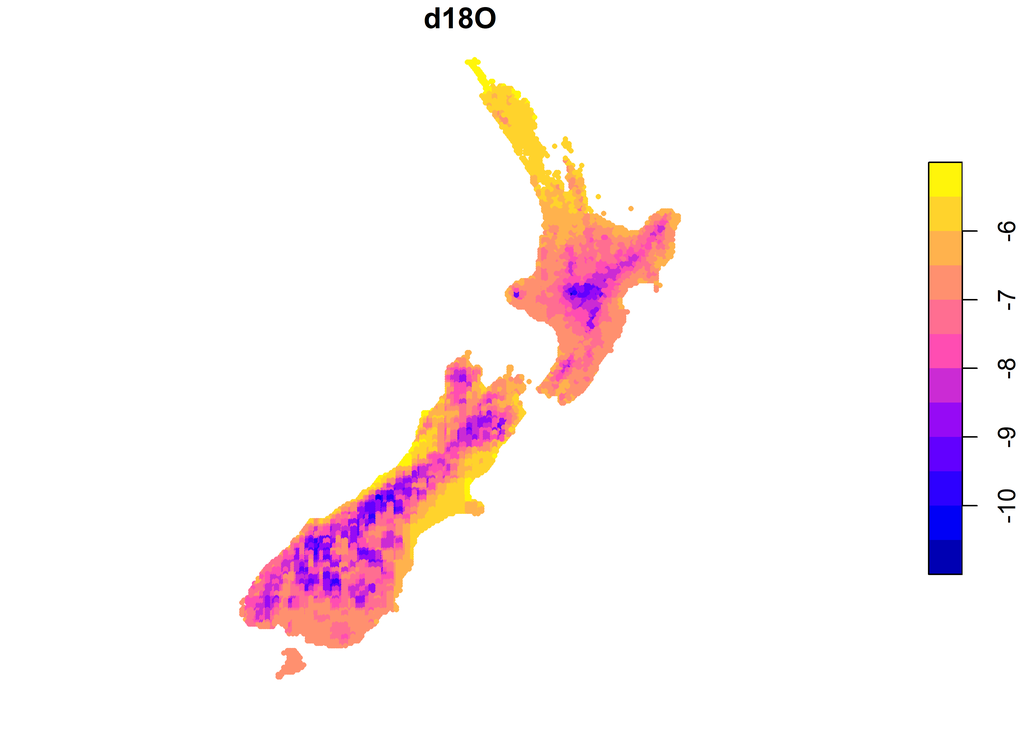

```r
nz_global_sf<-vcsn.agent.locations |> cbind(oxy.sf[st_nearest_feature(vcsn.agent.locations,oxy.sf),])
rownames(nz_global_sf)<-NULL
nz_global<-as.data.frame(nz_global_sf[,1:5])

plot(nz_global_sf["d18O"], cex = 0.5, pch = 16)
```

Then a loop to make a data frame

```r
nz_global_full<-nz_global[,1:3]
for (file in myfiles) {

rasta <- read_stars(paste0("data/GlobalModelBowenRevenaugh/", file))
sf=sf::st_as_sf(rasta, as_points = TRUE, crs = 4326)

modeldata.sf<-modeldata|>
  sf::st_as_sf(coords = c("vcsn.lon", "vcsn.lat"), crs = 4326)

oxy<-as.data.frame(sf)
locs<-sfheaders::sf_to_df(sf)[c("x", "y")]
oxy$d18O<-oxy[,1]
oxy$lat<-locs$x
oxy$lon<-locs$y
oxy<-oxy[,3:5]

oxy.sf<-oxy|>
  sf::st_as_sf(coords = c("lat", "lon"), crs = 4326)

dim(oxy.sf)

oxy.sf <- oxy.sf |>
  st_crop(xmin = 164.8, xmax = 179.4, ymin = -47.7, ymax = -33.8) |>
  st_transform(crs = 4326)

dim(oxy.sf)

nz_global_sf<-vcsn.agent.locations |> cbind(oxy.sf[st_nearest_feature(vcsn.agent.locations,oxy.sf),])

rownames(nz_global_sf)<-NULL
nz_global<-as.data.frame(nz_global_sf[,1:5])
  new <- nz_global$d18O  # Create new column of d18O preditions
  nz_global_full[ , ncol(nz_global_full) + 1] <- new                  # Append new column
  colnames(nz_global_full)[ncol(nz_global_full)] <- paste0("new", file)  # Rename column name
  print(paste0("finished ", file))
}
```

```
[1] "finished d18o_01.tif"
[1] "finished d18o_02.tif"
[1] "finished d18o_03.tif"
[1] "finished d18o_04.tif"
[1] "finished d18o_05.tif"
[1] "finished d18o_06.tif"
[1] "finished d18o_07.tif"
[1] "finished d18o_08.tif"
[1] "finished d18o_09.tif"
[1] "finished d18o_10.tif"
[1] "finished d18o_11.tif"
[1] "finished d18o_12.tif"
[1] "finished d18o_MA.tif"
```

```r
head(nz_global_full)
```

| Agent | vcsn.lon | vcsn.lat | newd18o_01.tif | newd18o_02.tif | newd18o_03.tif | newd18o_04.tif | newd18o_05.tif | newd18o_06.tif | newd18o_07.tif | newd18o_08.tif | newd18o_09.tif | newd18o_10.tif | newd18o_11.tif | newd18o_12.tif | newd18o_MA.tif |
| --- | --- | --- | --- | --- | --- | --- | --- | --- | --- | --- | --- | --- | --- | --- | --- |
| 3027 | 166.825 | -45.325 | -7.715364 | -7.333130 | -7.796207 | -8.043083 | -8.679805 | -8.915557 | -8.275452 | -8.253797 | -7.810645 | -7.525271 | -7.099953 | -7.095008 | -8.05591 |
| 3106 | 166.825 | -45.375 | -7.051322 | -6.639852 | -7.207521 | -7.400844 | -8.045084 | -8.256432 | -7.786597 | -7.834940 | -7.296262 | -6.955186 | -6.430305 | -6.441935 | -7.41545 |
| 3380 | 166.825 | -45.425 | -7.566484 | -7.185733 | -7.684431 | -7.896105 | -8.540032 | -8.766116 | -8.176580 | -8.172581 | -7.702073 | -7.407684 | -6.950831 | -6.955542 | -7.91538 |
| 4782 | 166.825 | -45.475 | -7.566484 | -7.185733 | -7.684431 | -7.896105 | -8.540032 | -8.766116 | -8.176580 | -8.172581 | -7.702073 | -7.407684 | -6.950831 | -6.955542 | -7.91538 |
| 5878 | 166.825 | -45.525 | -7.119381 | -6.720533 | -7.287770 | -7.464440 | -8.111887 | -8.321147 | -7.849361 | -7.894957 | -7.357442 | -7.025783 | -6.499810 | -6.516202 | -7.48305 |
| 7317 | 166.825 | -45.575 | -7.119381 | -6.720533 | -7.287770 | -7.464440 | -8.111887 | -8.321147 | -7.849361 | -7.894957 | -7.357442 | -7.025783 | -6.499810 | -6.516202 | -7.48305 |

From the chunk above, we make two dataframes to attach to the others. The first includes the global model predictions for each month, the second only has the VCSN points and the mean average isotope value of precipitation.

```r
nz_global_month<-nz_global_full[,c(1,4:15)]
nz_global_annual<-nz_global_full[,c(1,16)]
names(nz_global_month)<-c("Agent", "1", "2", "3", "4", "5", "6", "7", "8", "9", "10", "11", "12")
names(nz_global_annual)<-c("VCSN.Agent", "O18global.model")
nz_global_month<- gather(nz_global_month, month, "global18O", 2:13, factor_key=TRUE)
```

Attach to monthly data frame

```r
modeldata$global18O<-nz_global_month$global18O
```

Add mean monthly precipitation

```r
# cache = FALSE as a guessed solution to:
#
# Error in `lazyLoadDBinsertVariable()`:
# ! long vectors not supported yet: connections.c:6098
#

# load("ProcessedData/vcsn.2007.2022.RData")
#  - loaded at the start of the file

# names(vcsn.2007.2022)
#  [1] "Agent"   "Lat"     "Longt"   "Date"    "MSLP"    "PET"     "Rain"    "RH"      "SoilM"   "ETmp"    "Rad"     "TMax"    "Tmin"
# [14] "VP"      "Wind"    "Rain_bc" "Tmax_N"  "Tmin_N"

# vcsn.2007.2022cut <- vcsn.2007.2022[, c(1:4, 16)]
# rm(vcsn.2007.2022)
#  - moved to top of file

vcsn.2007.2022cut$Month <- format(as.Date(vcsn.2007.2022cut$Date, format = "%Y/%m/%d"), "%m")

# vcsn.2007.2022 doesn't have a year column
# vcsn.2007.2022cut$Year <- vcsn.2007.2022$Year
vcsn.2007.2022cut$Year <- format(as.Date(vcsn.2007.2022cut$Date, format = "%Y/%m/%d"), "%Y")

aggy1 <- aggregate(Rain_bc ~ Agent + Month + Year, data = vcsn.2007.2022cut, sum)
aggy2 <- aggregate(Rain_bc ~ Agent + Month, data = aggy1, mean)
names(aggy2) <- c("VCSN.Agent", "month", "Rain_bc")
aggy2$month <- as.numeric(aggy2$month)
aggy2$VCSN.Agent <- as.character(aggy2$VCSN.Agent)

modeldata <- left_join(aggy2, modeldata, by = c("VCSN.Agent", "month"))
write.csv(modeldata, "Output/MonthlyResiduals/monthly.isoscape.comparison.csv")


combine.vcsn.reg1 <- left_join(combine.vcsn.reg, RMSE.by.site, by = "Site")
```

These next data frames allow us to compare model representation of temporal AND spatial patterns in precipitation to those in measurements from the Frew dataset (Published as Baisden et al. 2016).

```r
rawdata <- ddata |> dplyr::select(Date, year, month, d18O, agent.number) |>
  rename(meas.18O = d18O, VCSN.Agent = agent.number)

head(rawdata)
```

| Date | year | month | meas.18O | VCSN.Agent |
| --- | --- | --- | --- | --- |
| 2007-08-15 | 2007 | 8 | -4.41 | 20661 |
| 2007-09-15 | 2007 | 9 | -5.71 | 20661 |
| 2007-10-15 | 2007 | 10 | -2.74 | 20661 |
| 2007-11-15 | 2007 | 11 | -4.72 | 20661 |
| 2007-12-15 | 2007 | 12 | -2.54 | 20661 |
| 2008-01-15 | 2008 | 1 | -4.70 | 20661 |

```r
checkdata <- left_join(rawdata, Baisden, by=c('year'='year', 'month'='month', 'VCSN.Agent' = 'VCSN.Agent'))

length(unique(checkdata$VCSN.Agent))
```

```
[1] 52
```

```r
modeldata2<-modeldata |> dplyr::select(VCSN.Agent, month, lin18O,  Allen18O,  Krig18O, unco.lin, unco.Allen, unco.krig)

checkdata$VCSN.Agent <- as.character(checkdata$VCSN.Agent)

checkdata<-dplyr::left_join(checkdata, modeldata2, by = c("VCSN.Agent", "month"))

monthly.checkdata<-rawdata|> dplyr::select(year, month, meas.18O, VCSN.Agent) |>
group_by(VCSN.Agent, month) |>
  summarise(meas.18O.mean = mean(meas.18O))
```

This third data frame allows us to compare representation of spatial patterns in precipitation. Here we are looking at unweighted annual means.

```r
modelmeans<- checkdata |>
  group_by(VCSN.Agent) |>
  summarise(meas.18O.mean = mean(meas.18O),
            Baisden18O.mean = mean(Baisden18O),
            lin18O.mean = mean(lin18O),
            Allen18O.mean = mean(Allen18O),
            Krig18O.mean = mean(Krig18O),
            unco.lin.mean = mean(unco.lin),
            unco.Allen.mean = mean(unco.Allen),
            unco.krig.mean = mean(unco.krig)
            )

nz_global_annual$VCSN.Agent <- as.character(nz_global_annual$VCSN.Agent)
modelmeans<-dplyr::inner_join(modelmeans, nz_global_annual, by = "VCSN.Agent")

head(modelmeans[,6:10])
```

| Krig18O.mean | unco.lin.mean | unco.Allen.mean | unco.krig.mean | O18global.model |
| --- | --- | --- | --- | --- |
| -5.867031 | -5.052524 | -5.613083 | -4.281803 | -7.05748 |
| -10.229019 | -7.760765 | -7.119562 | -8.366395 | -7.69751 |
| -7.459342 | -5.939830 | -5.773347 | -5.954190 | -6.90018 |
| -9.616757 | -6.759839 | -6.772354 | -5.815751 | -9.71548 |
| -9.674464 | -7.985682 | -7.427670 | -6.845283 | -8.06027 |
| -7.949819 | -5.173102 | -5.353920 | -5.471860 | -6.56464 |

## 4.3 Comparison with Kerr transect data

This fourth dataframe allows us to compare representation of spatial patterns across the south Island of New Zealand, where we know there are strong orographic effects. Here we are comparing our predictions with a transect of small streams from west to east across the SOuthern Alps published in Kerr et al. 2015 DOI:10.1175/JHM-D-13-0141.1

We will compare our three models (corrected and uncorrected) to that of Baisden et al. 2016 and the global model of Bowen&Revenaugh.

```r
kerr <- read.csv("data/Kerr.csv")
head(kerr)
```

| site | elevation | distance.from.tasman | long | lat | NZTME | NZTMN | O18_measured | H2_measured | Precip.18O | Precip.2H |
| --- | --- | --- | --- | --- | --- | --- | --- | --- | --- | --- |
| Kumara Stream | 19 | 0 | 171.1232 | -42.57453 | 1445974 | 5284723 | -5.5 | -33 | -6.56932 | -41.5524 |
| Stoney Creek | 118 | 14 | 171.2275 | -42.69479 | 1454809 | 5271554 | -4.1 | -23 | -6.80398 | -42.7650 |
| Culvert 51 | 66 | 20 | 171.2728 | -42.73321 | 1458614 | 5267364 | -5.2 | -29 | -7.16654 | -44.8416 |
| Harley Creek | 162 | 32 | 171.4545 | -42.73859 | 1473493 | 5267054 | -6.5 | -38 | -7.23494 | -46.1860 |
| Macs Creek | 156 | 30 | 171.4300 | -42.73997 | 1471493 | 5266864 | -6.5 | -38 | -7.29826 | -47.1640 |
| Humphreys Creek | 180 | 37 | 171.5120 | -42.74579 | 1478213 | 5266339 | -7.2 | -43 | -7.45740 | -50.3414 |

Make the kerr object have the same CRS as that of the vcsn agents simple features object, Then for each of the Kerr et al. (2015) sampling sites, find the nearest point on the VCSN grid. Join the modelling result dataframe to the Kerr dataframe based on this.

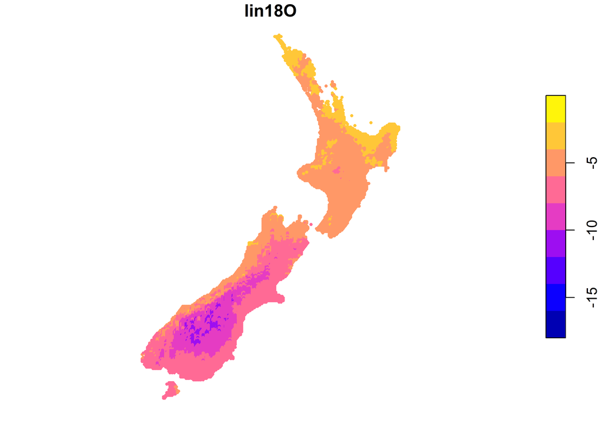

```r
kerr.sf <- kerr |>
  sf::st_as_sf(coords = c("long", "lat"), crs = 4326)

#make a df with unweighted annual means of all VCSN points
modeldata1<-st_drop_geometry(modeldata.sf)
modelmeans<- modeldata1 |>
  group_by(VCSN.Agent) |>
  summarise(lin18O.mean = mean(lin18O), Allen18O.mean = mean(Allen18O), Krig18O.mean = mean(Krig18O), unco.lin.mean = mean(unco.lin), unco.Allen.mean = mean(unco.Allen), unco.krig.mean = mean(unco.krig))
modelmeans<-dplyr::inner_join(modelmeans, nz_global_annual, by = "VCSN.Agent")
vcsn.agent.locations999<-st_drop_geometry(vcsn.agent.locations)
names(vcsn.agent.locations999)<-c("VCSN.Agent", "vcsn.lon", "vcsn.lat")

vcsn.agent.locations999$VCSN.Agent<-as.character(vcsn.agent.locations999$VCSN.Agent)
modelmeans<-dplyr::inner_join(modelmeans, vcsn.agent.locations999, by = "VCSN.Agent")


modelmeans1.sf<-modelmeans|>
  sf::st_as_sf(coords = c("vcsn.lon", "vcsn.lat"), crs = 4326)
joined_sf<-kerr.sf |> cbind(modelmeans1.sf[st_nearest_feature(kerr.sf, modelmeans1.sf),])
joined_sf<-joined_sf |> mutate(dist = st_distance(geometry, geometry.1, by_element = T))

plot(modeldata.sf["lin18O"], cex = 0.5, pch = 16)
```

```r
kerr.comparison<-st_drop_geometry(joined_sf)
names(kerr.comparison)<-c("site" , "elevation", "distance.from.tasman.sea",
                          "NZTME",  "NZTMN",
                          "O18_local_river" , "H2_local_river",
                          "Baisden18O", "Baisden2H",
                          "VCSN.Agent" ,
                          "lin18O.corrected",  "Allen18O.corrected",  "Krig18O.corrected",
                          "unco.lin", "unco.Allen" ,"unco.krig",
                          "O18global.model",
                          "geometry",
                          "distance to nearest VCSN point")

readr::write_csv(kerr.comparison, "Output/MonthlyResiduals/kerr_comparison.csv")
```

# 5 Saved data

```r
glimpse(combine.vcsn.reg)
```

```
Rows: 51
Columns: 32
$ Site                  <dbl> 1, 2, 3, 4, 5, 6, 7, 10, 11, 13, 14, 15, 16, 17,…
$ Amplitude             <dbl> 1.562325, 1.427132, 1.464083, 1.406172, 1.139799…
$ phase                 <dbl> -2.447313, -2.185044, -1.750229, -2.271231, -2.6…
$ offset                <dbl> -4.980762, -4.990002, -4.365129, -5.201198, -4.8…
$ area                  <chr> "Far North District", "Kaipara District", "Whang…
$ height                <dbl> 34.9724, 31.4201, 71.3756, 196.6477, 33.8324, 37…
$ island                <chr> "North Island", "North Island", "North Island", …
$ VCSN.lat              <dbl> -35.125, -35.975, -35.575, -35.425, -35.325, -34…
$ VCSN.lon              <dbl> 173.275, 173.925, 174.475, 173.825, 174.125, 172…
$ ETmp                  <dbl> 16.02943, 16.16725, 15.78417, 15.24098, 16.13272…
$ MSLP                  <dbl> 1017.120, 1016.914, 1017.205, 1016.628, 1017.069…
$ PET                   <dbl> 2.936140, 2.860849, 2.786037, 2.695568, 2.780869…
$ RH                    <dbl> 84.48234, 82.87960, 82.68727, 85.71193, 83.63652…
```

[output cut: 19 more lines]

```r
save(combine.vcsn.reg, file = "Output/Data/combine.vcsn.reg.RData")
```

```r
glimpse(meanBaisden)
```

```
Rows: 137,892
Columns: 3
Groups: VCSN.Agent [11,491]
$ VCSN.Agent <chr> "3027", "3027", "3027", "3027", "3027", "3027", "3027", "30…
$ month      <int> 1, 2, 3, 4, 5, 6, 7, 8, 9, 10, 11, 12, 1, 2, 3, 4, 5, 6, 7,…
$ Baisden18O <dbl> -5.776922, -6.123960, -6.951078, -7.667872, -8.648601, -8.8…
```

```r
save(meanBaisden, file = "Output/Data/meanBaisden.RData")
```

```r
glimpse(monthly.checkdata)
```

```
Rows: 609
Columns: 3
Groups: VCSN.Agent [52]
$ VCSN.Agent    <dbl> 7524, 7524, 7524, 7524, 7524, 7524, 7524, 7524, 7524, 75…
$ month         <dbl> 1, 2, 3, 4, 5, 6, 7, 8, 9, 10, 11, 12, 1, 2, 3, 4, 5, 6,…
$ meas.18O.mean <dbl> -5.213333, -8.340000, -6.513333, -7.103333, -7.053333, -…
```

```r
save(monthly.checkdata, file = "Output/Data/monthly.checkdata.RData")
```